# HOMEWORK 2 - SVM

PIERO CAVALCANTI - S252117 - 2018/2019

```python
print(__doc__)

import numpy as np
import matplotlib.pyplot as plt
from mpl_toolkits.mplot3d import Axes3D
from sklearn import datasets, svm
from sklearn.model_selection import train_test_split
from sklearn.decomposition import PCA
from sklearn.metrics import accuracy_score
from matplotlib.colors import Normalize
from sklearn.preprocessing import StandardScaler
from sklearn.model_selection import StratifiedShuffleSplit
from sklearn.model_selection import GridSearchCV
from sklearn.model_selection import ParameterGrid
import random
```

```
Automatically created module for IPython interactive environment
```

## 1. Linear SVM

Trying to solve a classification problem with a Linear separator using SVM. This model hardly perform good accuracy becouse of the behaviour of the real data-set, that in the most of the cases is not linear. The model selection is based on the two steps: a training stage based o the Training set, a validation stage to select the best C parameter (described below) using (in this case) the Validation set, and the representation of the model using the Test Set.

```python
#1 load Iris Dataset
iris = datasets.load_iris()
X = iris.data[:, :2]  #2 Simply select the first two dimensions
y = iris.target

#Normalize data
scaler = StandardScaler()
X = scaler.fit_transform(X)

print("Iris Data Matrix Shape = ",X.shape)
print("Iris Target Vector Shape = ",y.shape[0])
print("Iris Classes =",np.unique(y))

rs1=random.randint(1,1000)
rs2=random.randint(1,1000)

#3 Randomly split data into train, validation and test sets in proportion 5:2:3
X_train, X_test, y_train, y_test = train_test_split(X, y, test_size=0.3, random_state=rs1)
X_train, X_val, y_train, y_val = train_test_split(X_train, y_train, test_size=0.28, random_state=rs2)#0.28=2/7 -> 5:2:3 preserved
print("Size Train, validation, test = ",X_train.shape[0]/X.shape[0],X_val.shape[0]/X.shape[0],X_test.shape[0]/X.shape[0],)
print("Size Train, validation, test = ",X_train.shape[0],X_val.shape[0],X_test.shape[0])

#For C from 10^-3 to 10^3:
# a. Train a linear SVM on the training set.
# b. Plot the data and the decision boundaries
# c. Evaluate the method on the validation set

C_values = [10**(-3),10**(-2),10**(-1),10**(0),10**(1),10**(2),10**(3),]
C_range = np.logspace(-6, 4, 11)
gamma_range = np.logspace(-6, 4, 11)

def make_meshgrid(x, y, h=.02):
    """Create a mesh of points to plot in

    Parameters
    ----------
    x: data to base x-axis meshgrid on
    y: data to base y-axis meshgrid on
    h: stepsize for meshgrid, optional

    Returns
    -------
    xx, yy : ndarray
    """
    x_min, x_max = x.min() - 1, x.max() + 1
    y_min, y_max = y.min() - 1, y.max() + 1
    xx, yy = np.meshgrid(np.arange(x_min, x_max, h),
                         np.arange(y_min, y_max, h))
    return xx, yy


def plot_contours(ax, clf, xx, yy, **params):
    """Plot the decision boundaries for a classifier.

    Parameters
    ----------
    ax: matplotlib axes object
    clf: a classifier
    xx: meshgrid ndarray
    yy: meshgrid ndarray
    params: dictionary of params to pass to contourf, optional
    """
    Z = clf.predict(np.c_[xx.ravel(), yy.ravel()])
    Z = Z.reshape(xx.shape)
    out = ax.contourf(xx, yy, Z, **params)
    return out
```

```
Iris Data Matrix Shape =  (150, 2)
Iris Target Vector Shape =  150
Iris Classes = [0 1 2]
Size Train, validation, test =  0.5 0.2 0.3
Size Train, validation, test =  75 30 45
```

```
[0.36666666666666664, 0.36666666666666664, 0.7666666666666667, 0.8, 0.7333333333333333, 0.7333333333333333, 0.7333333333333333]
[0.001, 0.01, 0.1, 1, 10, 100, 1000]
```

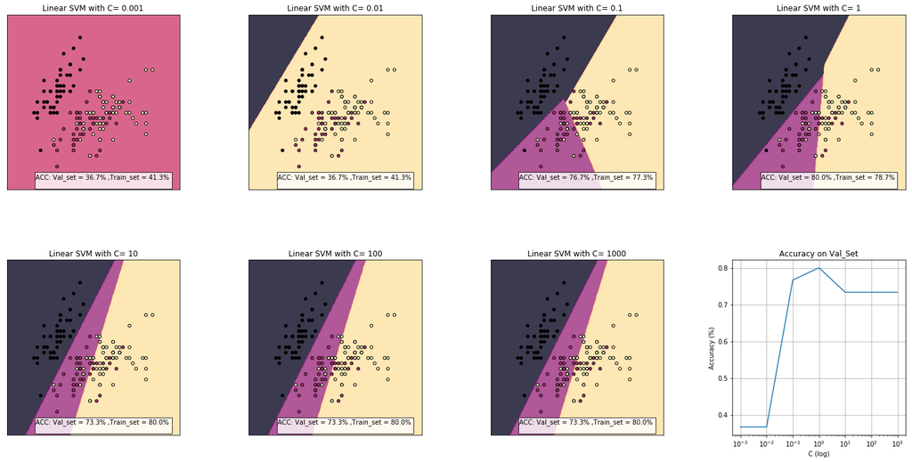

```python
fig, sub = plt.subplots(2, 4, figsize=(25, 12))
plt.subplots_adjust(wspace=0.4, hspace=0.4)
accuracy_values=[]


for C,ax in zip(C_values,sub.flatten()):
    svm_model=svm.SVC(kernel='linear',C=C)
    svm_model.fit(X_train, y_train)

    #valuate accuracy on validation set
    y_pred = svm_model.predict(X_val)
    #accuracy = accuracy_score(y_val, y_pred)
    accuracy = svm_model.score(X_val,y_val)

    X0, X1 = X[:, 0], X[:, 1]
    xx, yy = make_meshgrid(X0, X1)

    title = 'Linear SVM with C= '+str(C)
    ax.text(0.95, 0.01,
        ("ACC: Val_set = %0.1f%% " % (accuracy * 100))+(",Train_set = %0.1f%% " % (svm_model.score(X_train,y_train) * 100)+("\n")),
        bbox={'facecolor':'white', 'alpha':0.8, 'pad':1},
        verticalalignment='bottom', horizontalalignment='right',
        transform=ax.transAxes,
        color='black', fontsize=10)
    accuracy_values.append(accuracy)
   # print(accuracy_values)
    plot_contours(ax, svm_model, xx, yy, cmap=plt.cm.magma, alpha=0.8)
    ax.scatter(X0, X1, c=y, cmap=plt.cm.magma, s=20, edgecolors='k')
    ax.set_xlim(xx.min(), xx.max())
    ax.set_ylim(yy.min(), yy.max())
    ax.set_xticks(())
    ax.set_yticks(())
    ax.set_title(title)




#5. Plot a graph showing how the accuracy on the validation set varies when changing C
print (accuracy_values)
print(C_values)

ax=sub.flatten()[-1]
xg = C_values
yg =  accuracy_values

ax.plot(xg, yg)
ax.set_xscale('log')
ax.set(xlabel='C (log)', ylabel='Accuracy (%)',
       title='Accuracy on Val_Set')
ax.grid()


plt.show()
```

#### 6. How do the boundaries change? Why?

C represent the penalty parameter applied at the error term during the training algorithm of SVM; it means that: Choosing a big value for C means that errors are strongly penalized and thus it will leads to a **more accurate boundary in terms of misclassification error**. On the other hand, the classifier margin will be smaller when C is large (and overfitting is more probable). Again, a small C helps you to reach **a larger margin for your models**, but in return for less accuracy value.

In summary, "The C parameter trades off correct classification of training examples against maximization of the decision function’s margin".

There is not the "best" value for C, but it strongly depends on which kind of data you are using and which kind of results you want to get. As shown by the graphs behind, for C values smaller than 10^-2 the SVM algorithm does not reach a meaningfull solution, but as C grows as the model became effective and the accuracy on the training set get higher values (that, as said, it is not necessary a good behaviour)

```
ACCURACY= 0.8666666666666667
```

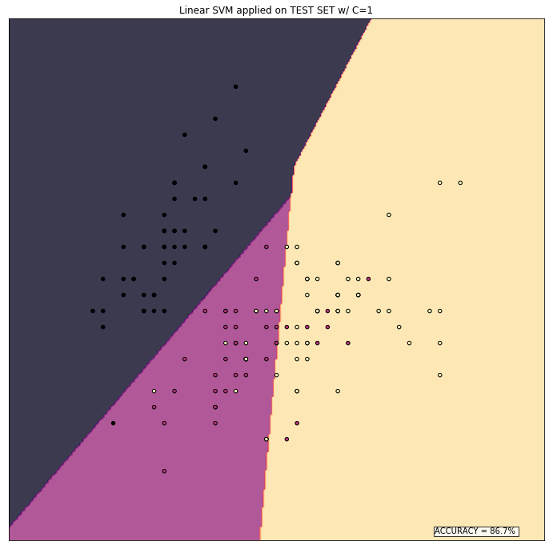

```python
#7. Use the best value of C and evaluate the model on the test set. How well does it go?


fig, sub = plt.subplots(1, 1, figsize=(12, 12))
plt.subplots_adjust(wspace=0.4, hspace=0.4)
ax=sub#.flatten()

sel_C = C_values[np.argmax(accuracy_values)]
svm_model=svm.SVC(kernel='linear',C=sel_C)#bestvalue
svm_model.fit(X_train, y_train)

accuracy = svm_model.score(X_test,y_test)
print("ACCURACY=",accuracy)

X0, X1 = X[:, 0], X[:, 1]
xx, yy = make_meshgrid(X0, X1)

title = 'Linear SVM applied on TEST SET w/ C=' + str(sel_C)
ax.text(0.95, 0.01,
    ("ACCURACY = %0.1f%% " % (accuracy * 100)),
    bbox={'facecolor':'white', 'alpha':0.8, 'pad':1},
    verticalalignment='bottom', horizontalalignment='right',
    transform=ax.transAxes,
    color='black', fontsize=10)
# print(accuracy_values)
plot_contours(ax, svm_model, xx, yy, cmap=plt.cm.magma, alpha=0.8)
ax.scatter(X0, X1, c=y, cmap=plt.cm.magma, s=20, edgecolors='k')
ax.set_xlim(xx.min(), xx.max())
ax.set_ylim(yy.min(), yy.max())
ax.set_xticks(())
ax.set_yticks(())
ax.set_title(title)
plt.show()
```

## 2. RBF-Kernel SVM

RBF Kernel allows to resolve not-linear problem thanks to the use of Radial basis function instead of the simple dot product. It allows to get a non-linear separator to retrieve a better classifier. The parameters to be tuned are the seen C and the gamma, that "defines how far the influence of a single training example reaches, with low values meaning ‘far’ and high values meaning ‘close’".

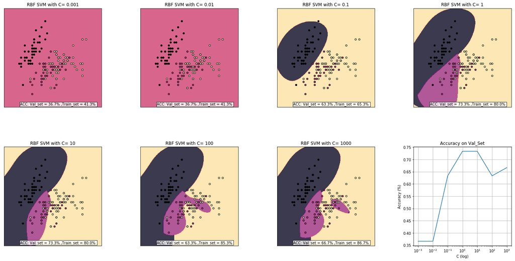

```python
fig, sub = plt.subplots(2, 4, figsize=(25, 12))
plt.subplots_adjust(wspace=0.4, hspace=0.4)
accuracy_values=[]


for C,ax in zip(C_values,sub.flatten()):
    svm_model=svm.SVC(kernel='rbf',C=C)
    svm_model.fit(X_train, y_train)

    #valuate accuracy on validation set
    y_pred = svm_model.predict(X_val)
    #accuracy = accuracy_score(y_val, y_pred)
    accuracy = svm_model.score(X_val,y_val)

    X0, X1 = X[:, 0], X[:, 1]
    xx, yy = make_meshgrid(X0, X1)

    title = 'RBF SVM with C= '+str(C)
    ax.text(0.95, 0.01,
        ("ACC: Val_set = %0.1f%% " % (accuracy * 100))+(",Train_set = %0.1f%% " % (svm_model.score(X_train,y_train) * 100)),
        bbox={'facecolor':'white', 'alpha':0.8, 'pad':1},
        verticalalignment='bottom', horizontalalignment='right',
        transform=ax.transAxes,
        color='black', fontsize=10)
    accuracy_values.append(accuracy)
    plot_contours(ax, svm_model, xx, yy, cmap=plt.cm.magma, alpha=0.8)
    ax.scatter(X0, X1, c=y, cmap=plt.cm.magma, s=20, edgecolors='k')
    ax.set_xlim(xx.min(), xx.max())
    ax.set_ylim(yy.min(), yy.max())
    ax.set_xticks(())
    ax.set_yticks(())
    ax.set_title(title)




#5. Plot a graph showing how the accuracy on the validation set varies when changing C

ax=sub.flatten()[-1]
xg = C_values
yg =  accuracy_values

ax.plot(xg, yg)
ax.set_xscale('log')
ax.set(xlabel='C (log)', ylabel='Accuracy (%)',
       title='Accuracy on Val_Set')
ax.grid()


plt.show()
```

```
ACCURACY= 0.8
PARAMS: {'C': 1, 'cache_size': 200, 'class_weight': None, 'coef0': 0.0, 'decision_function_shape': 'ovr', 'degree': 3, 'gamma': 1, 'kernel': 'rbf', 'max_iter': -1, 'probability': False, 'random_state': None, 'shrinking': True, 'tol': 0.001, 'verbose': False}
```

[figure not shown]

```python
fig, sub = plt.subplots(1, 1, figsize=(12, 12))
plt.subplots_adjust(wspace=0.4, hspace=0.4)
ax=sub#.flatten()


sel_C = C_values[np.argmax(accuracy_values)]

svm_model=svm.SVC(kernel='rbf',C=sel_C,gamma=1)#gamma has to be a fixed value to perform best C research
svm_model.fit(X_train, y_train)

accuracy = svm_model.score(X_test,y_test)
print("ACCURACY=",accuracy)
print("PARAMS: "+ str(svm_model.get_params()))
X0, X1 = X[:, 0], X[:, 1]
xx, yy = make_meshgrid(X0, X1)

title = 'Linear SVM applied on TEST SET'
ax.text(0.95, 0.01,
    ("ACCURACY = %0.1f%% " % (accuracy * 100)),
    bbox={'facecolor':'white', 'alpha':0.8, 'pad':1},
    verticalalignment='bottom', horizontalalignment='right',
    transform=ax.transAxes,
    color='black', fontsize=10)
# print(accuracy_values)
plot_contours(ax, svm_model, xx, yy, cmap=plt.cm.magma, alpha=0.8)
ax.scatter(X0, X1, c=y, cmap=plt.cm.magma, s=20, edgecolors='k')
ax.set_xlim(xx.min(), xx.max())
ax.set_ylim(yy.min(), yy.max())
ax.set_xticks(())
ax.set_yticks(())
ax.set_title(title)
plt.show()
```

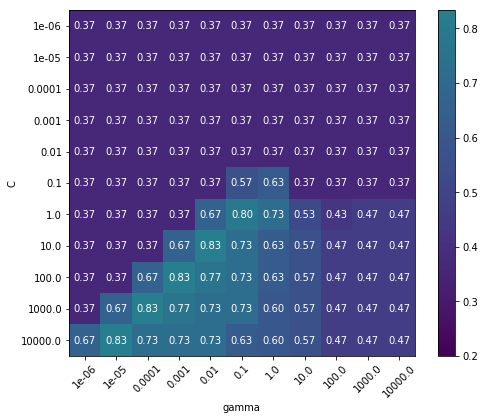

```python
#11. Perform a grid search of the best parameters for an RBF kernel: we will now
#tune both gamma and C at the same time. Select an appropriate range for
#both parameters. Train the model and score it on the validation set.

#12. Show the table showing how these parameters score on the validation set.

class MidpointNormalize(Normalize):

    def __init__(self, vmin=None, vmax=None, midpoint=None, clip=False):
        self.midpoint = midpoint
        Normalize.__init__(self, vmin, vmax, clip)

    def __call__(self, value, clip=None):
        x, y = [self.vmin, self.midpoint, self.vmax], [0, 0.5, 1]
        return np.ma.masked_array(np.interp(value, x, y))


param_grid = {'C':C_range,
              'gamma':gamma_range}

classifier= []

for z in list(ParameterGrid(param_grid)):
    clf=svm.SVC(kernel='rbf')
    clf.set_params(**z)
    clf.fit(X_train, y_train)
    classifier.append(clf)
    #print((clf.get_params,clf.score(X_val,y_val)))



# plot the scores of the grid
# grid_scores_ contains parameter settings and scores
scores = [el.score(X_val,y_val) for el in classifier]
selected_params = classifier[scores.index(max(scores))].get_params()
scores = np.array(scores).reshape(len(C_range), len(gamma_range))

# Make a nice figure
plt.figure(figsize=(8, 6))
plt.subplots_adjust(left=0.15, right=0.95, bottom=0.15, top=0.95)
plt.imshow(scores, interpolation='nearest', cmap=plt.cm.viridis,norm=MidpointNormalize(vmin=0.2, midpoint=0.94))
plt.xlabel('gamma')
plt.ylabel('C')
plt.colorbar()
plt.xticks(np.arange(len(gamma_range)), gamma_range, rotation=45)
plt.yticks(np.arange(len(C_range)), C_range)

# Loop over data dimensions and create text annotations.
for i in range(len(C_range)):
    for j in range(len(gamma_range)):
        text = plt.text(j, i, ("%0.2f" % scores[i, j]),
                       ha="center", va="center", color="w")


plt.show()
```

```
ACCURACY= 0.8666666666666667
PARAMS: {'C': 10.0, 'cache_size': 200, 'class_weight': None, 'coef0': 0.0, 'decision_function_shape': 'ovr', 'degree': 3, 'gamma': 0.01, 'kernel': 'rbf', 'max_iter': -1, 'probability': False, 'random_state': None, 'shrinking': True, 'tol': 0.001, 'verbose': False}
```

[figure not shown]

```python
#13. Evaluate the best parameters on the test set. Plot the decision boundaries


fig, sub = plt.subplots(1, 1, figsize=(12, 12))
plt.subplots_adjust(wspace=0.4, hspace=0.4)
ax=sub#.flatten()

svm_model=svm.SVC(kernel='rbf')
svm_model.set_params(**selected_params)
svm_model.fit(X_train, y_train)

accuracy = svm_model.score(X_test,y_test)
print("ACCURACY=",accuracy)
print("PARAMS: "+ str(svm_model.get_params()))
X0, X1 = X[:, 0], X[:, 1]
xx, yy = make_meshgrid(X0, X1)

title = 'Linear SVM applied on TEST SET'
ax.text(0.95, 0.01,
    ("ACCURACY = %0.1f%% " % (accuracy * 100)),
    bbox={'facecolor':'white', 'alpha':0.8, 'pad':1},
    verticalalignment='bottom', horizontalalignment='right',
    transform=ax.transAxes,
    color='black', fontsize=10)
# print(accuracy_values)
plot_contours(ax, svm_model, xx, yy, cmap=plt.cm.magma, alpha=0.8)
ax.scatter(X0, X1, c=y, cmap=plt.cm.magma, s=20, edgecolors='k')
ax.set_xlim(xx.min(), xx.max())
ax.set_ylim(yy.min(), yy.max())
ax.set_xticks(())
ax.set_yticks(())
ax.set_title(title)
plt.show()
```

Without a cross-validation grid search method, the training and validation could perform an inaccurate and strongly over-fitted model selection. So it is really important to use a cross-validation (like the example below) to reach better results.

## 3. K-Fold Validation

```python
#Merge the training and validation split. You should now have 70% training and 30% test data
X_train, X_test, y_train, y_test = train_test_split(X, y, test_size=0.3, random_state=rs1)
print("Size Train, test = ",X_train.shape[0]/X.shape[0],X_test.shape[0]/X.shape[0],)
print("Size Train, test = ",X_train.shape[0],X_test.shape[0])

X_fold = np.array_split(X_train, 5)
y_fold = np.array_split(y_train, 5)
```

```
Size Train, test =  0.7 0.3
Size Train, test =  105 45
```

```python
param_grid = dict(gamma=gamma_range, C=C_range)
grid = GridSearchCV(svm.SVC(kernel='rbf'), param_grid=param_grid,cv=5)
grid.fit(X_train, y_train)


print("The best parameters are %s with a score of %0.2f"
      % (grid.best_params_, grid.best_score_))
```

```
The best parameters are {'C': 10.0, 'gamma': 0.01} with a score of 0.76
```

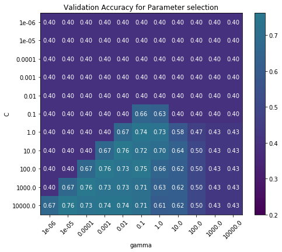

```python
scores = grid.cv_results_['mean_test_score'].reshape(len(C_range),
                                                     len(gamma_range))
plt.figure(figsize=(8, 6))
plt.subplots_adjust(left=.2, right=0.95, bottom=0.15, top=0.95)
plt.imshow(scores, interpolation='nearest', cmap=plt.cm.viridis,
    norm=MidpointNormalize(vmin=0.2, midpoint=0.9))
plt.xlabel('gamma')
plt.ylabel('C')
plt.colorbar()
plt.xticks(np.arange(len(gamma_range)), gamma_range, rotation=45)
plt.yticks(np.arange(len(C_range)), C_range)
plt.title('Validation Accuracy for Parameter selection')


# Loop over data dimensions and create text annotations.
for i in range(len(C_range)):
    for j in range(len(gamma_range)):
        text = plt.text(j, i, ("%0.2f" % scores[i, j]),
                       ha="center", va="center", color="w")

plt.show()
```

```
ACCURACY= 0.8888888888888888
PARAMS: {'C': 10.0, 'cache_size': 200, 'class_weight': None, 'coef0': 0.0, 'decision_function_shape': 'ovr', 'degree': 3, 'gamma': 0.01, 'kernel': 'rbf', 'max_iter': -1, 'probability': False, 'random_state': None, 'shrinking': True, 'tol': 0.001, 'verbose': False}
```

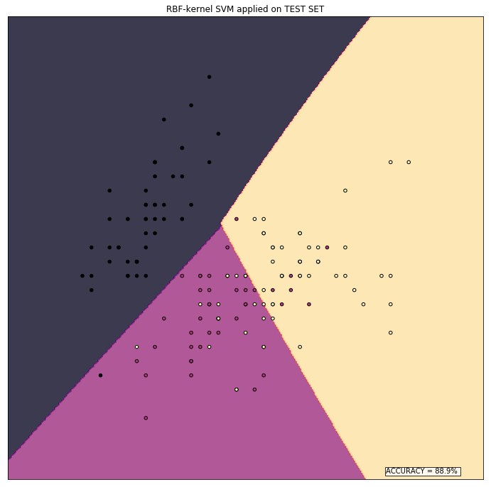

```python
#13. Evaluate the best parameters on the test set. Plot the decision boundaries


fig, sub = plt.subplots(1, 1, figsize=(12, 12))
plt.subplots_adjust(wspace=0.4, hspace=0.4)
ax=sub

svm_model=svm.SVC(kernel='rbf')
svm_model.set_params(**grid.best_params_)
svm_model.fit(X_train, y_train)

accuracy = svm_model.score(X_test,y_test)
print("ACCURACY=",accuracy)
print("PARAMS: "+ str(svm_model.get_params()))
X0, X1 = X[:, 0], X[:, 1]
xx, yy = make_meshgrid(X0, X1)

title = 'RBF-kernel SVM applied on TEST SET'
ax.text(0.95, 0.01,
    ("ACCURACY = %0.1f%% " % (accuracy * 100)),
    bbox={'facecolor':'white', 'alpha':0.8, 'pad':1},
    verticalalignment='bottom', horizontalalignment='right',
    transform=ax.transAxes,
    color='black', fontsize=10)
# print(accuracy_values)
plot_contours(ax, svm_model, xx, yy, cmap=plt.cm.magma, alpha=0.8)
ax.scatter(X0, X1, c=y, cmap=plt.cm.magma, s=20, edgecolors='k')
ax.set_xlim(xx.min(), xx.max())
ax.set_ylim(yy.min(), yy.max())
ax.set_xticks(())
ax.set_yticks(())
ax.set_title(title)
plt.show()
```

**16. Evaluate the parameters on the test set. Is the final score different? Why?**

Said that, the test experiment results seems the natural consequence: an overfitted model performs a strong accuracy on the Train and Validation Set, but not works well (or at all) on unseen data (Test set). But when model tuning is balanced and the model is "well-fitted", it will perform better accuracy on the test set, though the accuracies on Training or Validation could not seems to drive to the best result.